# Cross-validation and group-cross-validation in INLA

Zhedong Liu (zhedong.liu@kaust.edu.sa)

Dec 2023

We present examples to illustrate the use of leave-group-out cross-validation (LGOCV) in INLA. The first example demonstrates the primary function used to compute the LGOCV, while the second example introduces additional features. For more advanced examples, please refer to (Adin et al. 2023).

Let us assume that we have collected repetitive measurements of the weights of some rats with measurement errors. We denote each measurement as $y_i$, and each $y_i$ is associated with the ID of the corresponding rat, denoted as $id_i$. For the purposes of our analysis, we have simulated the data according to a true model. Specifically, we have simulated data for 10 rats, each with 10 measurements. We then plot the vector $\boldsymbol{y}$ against the group ID for each measurement.

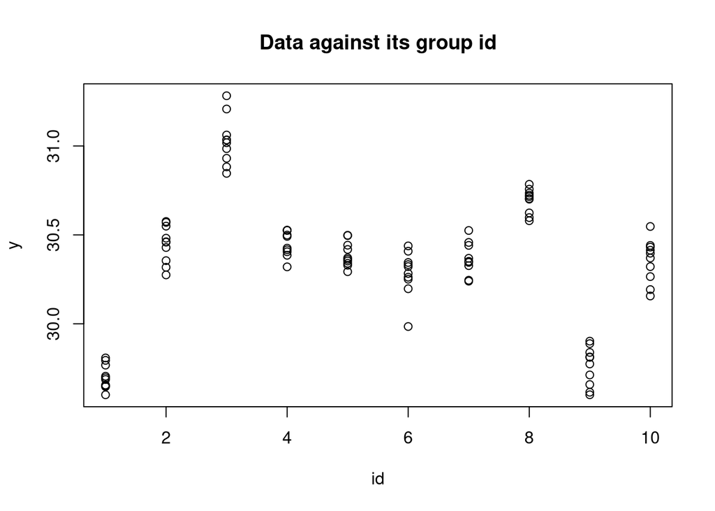

We can fit a multilevel model to the data and use it to make two types of predictions. The first prediction is to estimate the weight of another measurement from rat one, while the second prediction is to estimate the weight of a measurement from another rat. In INLA, there is no separate predict function for making predictions. Instead, predictions are made as a part of the model fitting process itself. Since making predictions is essentially the same as fitting a model with some missing data, we can simply set y[i] = NA for those locations for which we wish to make predictions.

```r
data = data.frame(y = c(y,rep(NA,n_rat+1)),id = c(id,1:n_rat,n_rat+1))
formula = y ~ 1 + f(id,model = "iid")
res = inla(formula = formula,
           data = data,
           family = "normal"
           )
```

```r
##
## this example needs to be fixed so it does not depend on the removed
## inla.likelihood* feature
##
res = inla(formula = formula,
           data = data.frame(y = c(y,rep(NA,n_rat+1)), id = c(id,1:n_rat,n_rat+1)),
           family = "normal",
           control.compute = list(config = TRUE,likelihood.info = T)
           )
nconfig = res$misc$configs$nconfig
weights = unlist(lapply(1:nconfig,FUN = function(i){res$misc$configs$config[[i]]$log.posterior}))
weights = exp(weights)/sum(exp(weights))
eps = 0.001
q = seq(eps,1-eps,eps)
preddensity = vector(mode = "list",length = n_rat+1)
for(rat_idx in c(1,11)){
    predictor_idx = n + rat_idx
    mode_idx = which.max(weights)
    args = INLA:::inla.likelihood.parser(res$misc$configs$config[[1]]$arg.str[1])
    for(mode_idx in mode_idx){
        args$theta = res$misc$configs$config[[mode_idx]]$theta[1]
        mode_eta_mu = res$misc$configs$config[[mode_idx]]$Predictor[predictor_idx,"mean"]
        mode_eta_sd = sqrt(res$misc$configs$config[[mode_idx]]$Predictor[predictor_idx,"variance"])
        eta_eval = mode_eta_mu + seq(-5,5)*mode_eta_sd
        args$linear.predictor = eta_eval
        qfunc = inla.likelihood(type = "q",args)
        y_eval = c()
        for(i in 1:length(q)){
            y_eval = c(y_eval,qfunc(q[i]))
        }
    }
    y_eval = sort(y_eval)

    preddensity_conditional = list(mode = "list",length = nconfig)
    preddensity[[rat_idx]]$y_eval = y_eval
    preddensity[[rat_idx]]$density = numeric(length(y_eval))
    for(config_idx in 1:nconfig){
        args$theta = res$misc$configs$config[[config_idx]]$theta[1]
        preddensity_conditional[[config_idx]] = inla.lik.pred(y_eval,
                                                  args = args,
                                                  eta.mean = res$misc$configs$config[[config_idx]]$Predictor[predictor_idx,"mean"],
                                                  eta.sd = sqrt(res$misc$configs$config[[config_idx]]$Predictor[predictor_idx,"variance"])
                                                  )
        preddensity[[rat_idx]]$density  = preddensity[[rat_idx]]$density +  weights[config_idx]*preddensity_conditional[[config_idx]]
    }
}
plot(preddensity[[1]]$y_eval,preddensity[[1]]$density,
     main = "Predictive Density of A Measure from Rat 1",
     xlab = "weight",
     ylab = "density",
     type="l")
plot(preddensity[[11]]$y_eval,preddensity[[11]]$density,
     main = "Predictive Density of A Measure from An Unobserved Rat",
     xlab = "weight",
     ylab = "density",
     type="l")
```

[output not shown]

To evaluate the accuracy of the first prediction, we can use LOOCV with a logarithmic utility. The LOOCV logarithmic utility can be expressed as:
$$U_{\text{LOOCV}} =
\frac{1}{n}\sum_{i = 1}^n \log \pi(Y_i
= y_i| \boldsymbol{y}_{-i}).$$

To assess the quality of the second prediction, we can use leave-group-out cross-validation (LGOCV), where the group includes all measurements from a particular rat. The LGOCV logarithmic utility can be expressed as:
$$U_{LGOCV} =
\frac{1}{n}\sum_{i = 1}^n \log \pi(Y_i =
y_i|\boldsymbol{y}_{-I_i}).$$
Here, $I_i$ represents the indices of data points from the same rat. We can compute $U_{\text{LOOCV}}$ and $U_{\text{LGOCV}}$ using the inla.group.cv function.

```r
loocv_res = inla.group.cv(result = res)
ULOOCV = mean(log(loocv_res$cv[1:n]))

groups = lapply(1:n,FUN = function(i){which(id == id[i])})
lgocv_res = inla.group.cv(result = res,groups = groups)
ULGOCV = mean(log(lgocv_res$cv[1:n]))

print(paste0("ULOOCV is ", round(ULOOCV,5),"."))
print(paste0("ULGOCV is ", round(ULGOCV,5),"."))
```

```
[1] "ULOOCV is 0.83438."
[1] "ULGOCV is -0.56617."
```

In the previous code, we manually provided the groups. However, `inla.group.cv` also has the ability to automatically construct groups for LGOCV. This method was described in a preprint by (Liu and Rue 2022). Using this automatic method, the resulting groups are the same as the manual ones we provided earlier. The extra data points $101$ does not have effect on the result since $y_{101}$ is `NA`.

```r
lgocv_auto_res = inla.group.cv(result = res,num.level.sets = 1)
ULGOCV_auto = mean(log(lgocv_auto_res$cv[1:n]))
print(paste0("ULGOCV_auto is ", round(ULGOCV_auto,5),"."))
print(paste0("The group for data point 1 is:"))
print(paste(lgocv_auto_res$groups[[1]]$idx,collapse=" "))
```

```
[1] "ULGOCV_auto is -0.56617."
[1] "The group for data point 1 is:"
[1] "1 2 3 4 5 6 7 8 9 10"
```

The automatic construction of the groups is based on the posterior correlation coefficients of linear predictors. The parameter `num.level.sets` controls the degree of independence between $y_i$ and $\boldsymbol{y}_{-I_i}$. Higher `num.level.sets` means higher independence between $y_i$ and $\boldsymbol{y}_{-I_i}$.

We use a small example to illustrate the meaning of `num.level.sets = 3`. If $C_i$ contains the correlation of all $j$ to $i$, we construct the group for $i$ using the following procedure.

```r
num.level.sets = 3
# We intentionally create some replicated correlations since it is not rare to have
#|corr(eta_i,eta_j)| == |corr(eta_i,eta_k)|, where j != k.
C_i = c(1,1,0.9,0.9,0.8,0.8,-0.1,-0.1,0,0)
# L_i contains the correlation levels.
L_i = sort(unique(abs(C_i)),decreasing = T)
# Now we construct I_i
I_i = c()
for (l in 1:num.level.sets){
  I_i = c(I_i,which(abs(C_i) == L_i[l]))
}
print(paste(I_i,collapse=" "))
```

```
[1] "1 2 3 4 5 6"
```

We have multiple weight measurements for several rats denoted by $y_i$, each with an associated rat id $id_i$, and a covariate $x_i$ associated with each measurement but not with the rat.

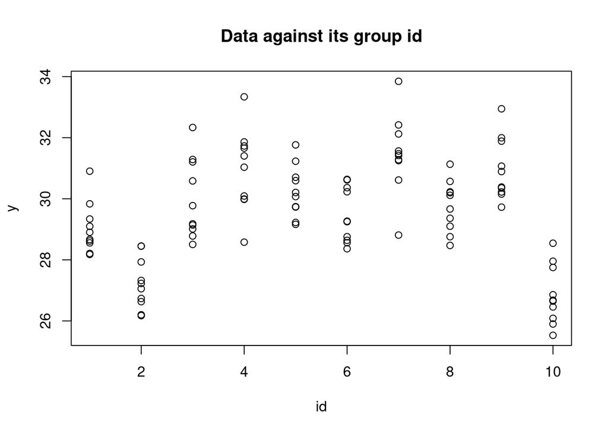

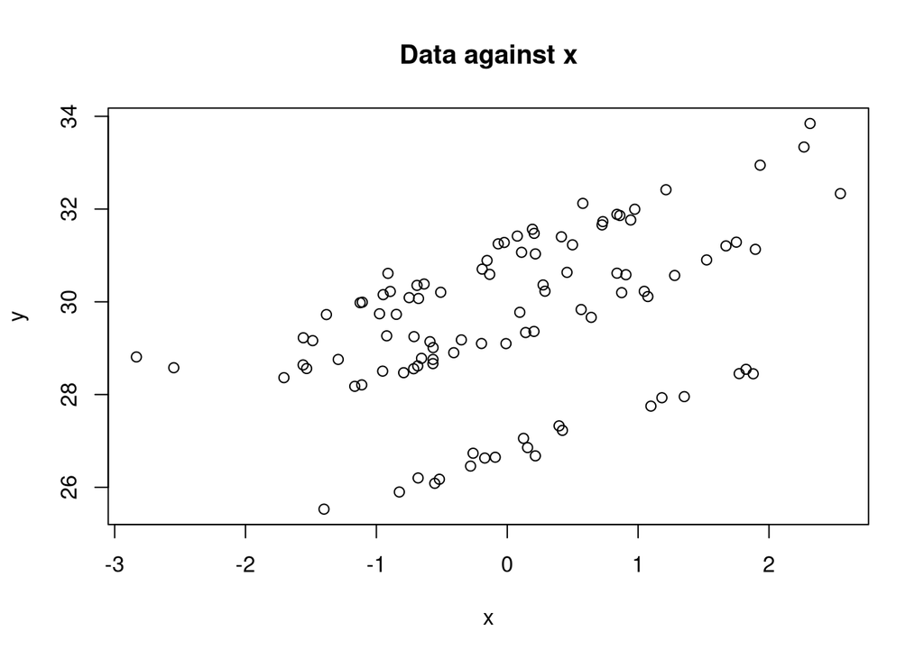

We fit a multilevel model with random intercepts and random slopes.

```r
data = data.frame(y = y,id = id,id2 = id,x = x)
formula = y ~ 1 + x + f(id, model = "iid") + f(id2, W = x,model = "iid")
res = inla(formula = formula,
           data = data,
           family = "normal",
           control.compute = list(config = TRUE,likelihood.info = T)
           )
```

We want to compare two models: one with random slopes and one without random slopes. To ensure that we have the same groups for the different models, we can pass an `inla.group.cv` class object to `inla.group.cv` function. Here is an example:

We first fit the model without random slopes.

```r
formula_alt =  y ~ 1 + x + f(id, model = "iid")
res_alt = inla(formula = formula_alt,
           data = data,
           family = "normal",
           control.compute = list(config = TRUE,likelihood.info = T)
           )
```

If we want to use the groups constructed by the full model to compute LGOCV, we have the following code.

```r
lgocv_res = inla.group.cv(result = res,num.level.sets = 1)
lgocv_res_alt = inla.group.cv(result = res_alt,group.cv = lgocv_res)
```

We check the result using automatic groups construction. We first check the group for data point 1, 2 and 3.

```r
lgocv_res = inla.group.cv(result = res,num.level.sets = 1)
print(paste(lgocv_res$groups[[1]]$idx,collapse=" "))
print(paste(lgocv_res$groups[[2]]$idx,collapse=" "))
print(paste(lgocv_res$groups[[3]]$idx,collapse=" "))
```

```
[1] "1"
[1] "2"
[1] "3"
```

The groups are different from the manual group. The reason is that the posterior correlation of the linear predictors considering all the effects including the linear effects and the `iid` effects. The manual group is formed based on the prior information of the `iid` effect. We can pass the message to the automatic construction through `keep` option, which should work with `strategy = "prior"`. That means we construct groups using prior correlation with only effects specified by the arguments `keep`.

```r
lgocv_res = inla.group.cv(result = res,num.level.sets = 1,strategy = "prior",keep = "id")
print(paste(lgocv_res$groups[[1]]$idx,collapse=" "))
print(paste(lgocv_res$groups[[2]]$idx,collapse=" "))
print(paste(lgocv_res$groups[[3]]$idx,collapse=" "))
```

```
[1] "1 2 3 4 5 6 7 8 9 10"
[1] "1 2 3 4 5 6 7 8 9 10"
[1] "1 2 3 4 5 6 7 8 9 10"
```

In some applications, we may not want to iterate over the whole data set. A typical scenario is that we are working on a very large data set. To select a subset as our testing points, we can use `select` arguments in `inla.group.cv`. Here is an example. We only want to have $12$th data point and $53$th data point as our testing points.

```r
lgocv_res = inla.group.cv(result = res,num.level.sets = 1,select = c(12,53))
```

In this way, we only compute quantities related to $\pi(y_{12}|\boldsymbol{y}_{-I_{12}})$ and $\pi(y_{53}|\boldsymbol{y}_{-I_{53}})$.

If we are using manual groups construct we only need to specify the groups for $12$th and $53$th data point.

```r
groups = vector(mode = "list",length = n)
groups[[12]] = which(id==id[12])
groups[[53]] = which(id==id[53])
lgocv_res = inla.group.cv(result = res,groups = groups)
```

To speed up the computation speed, `inla.group.cv` computes $\pi(y_i|\boldsymbol{\theta}^*,\boldsymbol{y}_{-I_i})$, where $\boldsymbol{\theta}^*$ is the mode of $\pi(\boldsymbol{\theta}|\boldsymbol{y})$. In order to compute $\pi(y_i|\boldsymbol{y}_{-I_i}) = \int \pi(y_i|\boldsymbol{\theta},\boldsymbol{y}_{-I_i}) \pi(\boldsymbol{\theta}|\boldsymbol{y}_{-I_i})d \boldsymbol{\theta}$, we need to enable the `control.gcpo` option while fitting the model, which is in `control.compute`. The result are stored in `res$gcpo` in the same format as the output of the `inla.group.cv`. Here is the example code.

```r
control.gcpo = list(enable = TRUE,num.level.sets = 1)
res = inla(formula = formula,
           data = data,
           family = "normal",
           control.compute = list(control.gcpo = control.gcpo,config = TRUE)
           )
```

In the outputs of `inla.group.cv`, we have access to mean (`lgocv.res$mean`) and standard deviation(`lgocv.res$sd`) of a Gaussian approximation of $\pi(\eta_i|\boldsymbol{\theta}^*,\boldsymbol{y}_{-I_i})$. With this we can compute any scoring rules, which is a function of the observed data $y_i$ and the predictive density $\pi(Y_i|\boldsymbol{\theta}^*,\boldsymbol{y}_{-I_i})$. The predictive density can be computed by the integral:
$$\pi(Y_i|\boldsymbol{\theta}^*,\boldsymbol{y}_{-I_i})
= \int
\pi(Y_i|\eta_i,\boldsymbol{\theta}^*)
\pi(\eta_i|\boldsymbol{\theta}^*,\boldsymbol{y}_{-I_i})d\eta_i,$$
where the likelihood $\pi(Y_i|\eta_i,\boldsymbol{\theta}^*)$ is given by the model and the posterior is contained in the outputs.

If we want to also integrate out the uncertainty of the hyperparameters, we need to compute
$$\pi(Y_i|\boldsymbol{\theta},\boldsymbol{y}_{-I_i})
= \int
\pi(\boldsymbol{\theta}|\boldsymbol{y}_{-I_i})\int
\pi(Y_i|\eta_i,\boldsymbol{\theta})
\pi(\eta_i|\boldsymbol{\theta},\boldsymbol{y}_{-I_i})d\eta_i
d\boldsymbol{\theta},$$
where $\pi(\boldsymbol{\theta}|\boldsymbol{y}_{-I_i})$ is computed using $\pi(\boldsymbol{\theta}|\boldsymbol{y}_{-I_i}) \propto \frac{\pi(\boldsymbol{\theta}|\boldsymbol{y})}{f(\boldsymbol{\theta}|\boldsymbol{y}_{I_i})}$. (Liu and Rue 2022) The location of each component is organized in the following list:

$\log \pi(\boldsymbol{\theta}|\boldsymbol{y})$ is contained in

`res$misc$configs$config[k]$log.posterior`.

The correction term $-\log f(\boldsymbol{\theta}|\boldsymbol{y}_{I_i})$ is contained in

`res$misc$configs$config[[1]]$gcpodens.moments[,"log.theta.correction"]`.

The mean of $\pi(\eta_i|\boldsymbol{\theta},\boldsymbol{y}_{-I_i})$ is contained in

`res$misc$configs$config[[1]]$gcpodens.moments[,"mean"]`.

The variance of $\pi(\eta_i|\boldsymbol{\theta},\boldsymbol{y}_{-I_i})$ is contained in

`res$misc$configs$config[[1]]$gcpodens.moments[,"variance"]`.

As an example, we compute the Continuous Ranked Probability Score (CRPS) and present its definition. Suppose $Y$ is a random variable with cumulative distribution function $F(y)$, and let $y_{observed}$ be the observed value. The CRPS is defined as:
$$CRPS(F,y_{observed})
= \int_{-\infty}^{\infty}(F(y)-(\boldsymbol{1}_{y \geq
y_{observed}}))^2dy,$$
where $\boldsymbol{1}{y \geq y{observed}}$ is the indicator function that takes the value 1 when $y \geq y_{observed}$ and 0 otherwise.

To evaluate the non-parametric predictive density, we obtain samples by first sampling $\boldsymbol{\theta}$ from $\pi(\boldsymbol{\theta}|\boldsymbol{y}{-I_i})$, then sampling $\pi(\eta_i|\boldsymbol{\theta},\boldsymbol{y}{-I_i})$, and finally obtaining samples of the predictive density by sampling from $\pi(Y_i|\eta_i,\boldsymbol{\theta})$. With the samples of the predictive density, we can compute its empirical cumulative function to evaluate $CRPS(F,y_{observed})$. The following code demonstrates this process:

```r
control.gcpo = list(enable = TRUE,num.level.sets = 1,strategy = "prior",keep = "id")
res = inla(formula = formula,
           data = data,
           family = "normal",
           control.compute = list(control.gcpo = control.gcpo,config = TRUE)
           )
# 1. choose the testing point
testing.point = 1
y_observed = y[testing.point]
# 2. get the hyperparameter density
nconfigs = res$misc$configs$nconfig
weights = unlist(lapply(X = 1:nconfigs,
    FUN = function(config.idx){
    res$misc$configs$config[[config.idx]]$log.posterior
    + res$misc$configs$config[[config.idx]]$gcpodens.moments[testing.point,3]
    }))
weights = exp(weights)/sum(exp(weights))
#3. get samples of y_i|y_{-I_i},theta
n = 1e6
n_theta = as.numeric(rmultinom(n = 1,size = n,prob = weights))
y_sample = c()
for(config.idx in 1:nconfigs){
    if(n_theta[config.idx]>0){
        eta = rnorm(n_theta[config.idx],
            mean = res$misc$configs$config[[config.idx]]$gcpodens.moments[testing.point,1],
            sd = sqrt(res$misc$configs$config[[config.idx]]$gcpodens.moments[testing.point,2]))
         sd = sqrt(1/exp(res$misc$configs$config[[config.idx]]$theta[1]))
         y_sample_config = rnorm(n = n_theta[config.idx],mean = eta,sd = sd)
         y_sample = c(y_sample,y_sample_config)
    }
}
#4 We can use y_sample to compute the empirical cumulative function then evaluate CRPS
F_y = function(y){sum(y_sample<=y)/n} #inefficient but straightforward...
yy = seq(min(y_sample)-10,max(y_sample)+10,0.01)
FF = unlist(lapply(yy,F_y))
CRPS = pracma::trapz(yy,(FF-(yy>=y_observed))^2)
```

# References

Adin, A, E Krainski, A Lenzi, Z Liu, J Martínez-Minaya, and H Rue. 2023. “Automatic Cross-Validation in Structured Models: Is It Time to Leave Out Leave-One-Out?” *arXiv Preprint arXiv:2311.17100*.

Liu, Zhedong, and Haavard Rue. 2022. “Leave-Group-Out Cross-Validation for Latent Gaussian Models.” *arXiv Preprint arXiv:2210.04482*.